# replication

Nick F & Aaron K

March 15, 2015

### Study 1a

" In this study, there were 103 participants (mean age = 29.3 years; median household size = 3 people; median household income = $35,000). One participant was excluded as an outlier on income (more than 3 SD from the mean). We conducted binary logistic regressions to compare how frequently participants cited each of the two considerations of interest (trade-offs vs. location) as a function of income."

```
##   average_age
## 1        29.3
```

```
## Source: local data frame [2 x 2]
##
##   V4 sex_breakdown
## 1  f            44
## 2  m            59
```

```
##   sample.size median.household.income median.household.size
## 1         103                   35000                     3
```

“Higher-income participants were more likely than lower-income participants to name location as the main consideration, β = 2.52, Wald-test χ2(1, N = 102) = 5.54, p < .05,”

```
##     term beta      p
## 1 logses 2.52 0.0186
```

```
## chi2
## 5.54
```

" but lower-income participants were more likely than higher- income participants to name trade-offs as the main consideration, β = −1.62, Wald-test χ2(1, N = 102) = 4.67, p <.05."

```
##     term  beta      p
## 1 logses -1.62 0.0307
```

```
## chi2
## 4.67
```

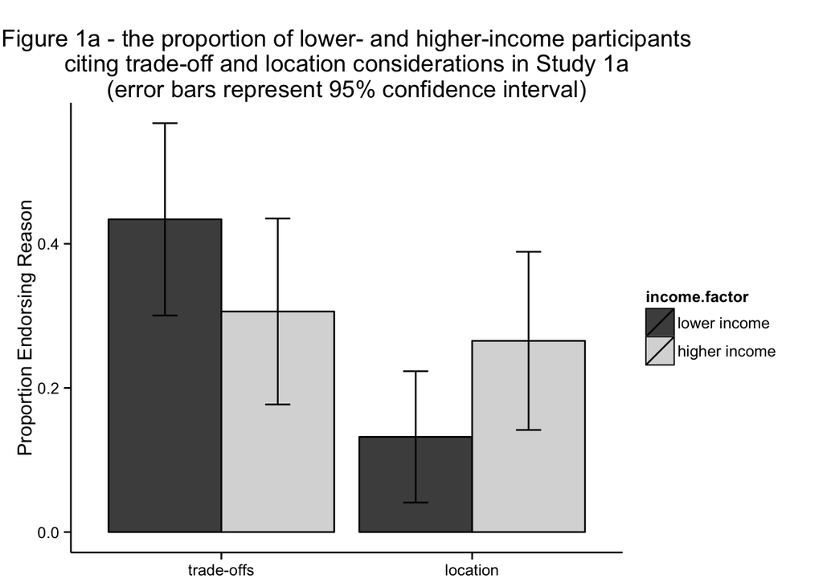

### Study 1b

“In Study 1b, there were 151 participants (mean age = 32.9 years; 76 females, 75 males; median household size = 3 people, median household income = $45000). In Study 1c, there were 604 participants (mean age = 29.9 years; 246 females, 358 males; median household size = 2 people; median household income = $45,000). Study 1d was conducted with a large, representative sample drawn from Survey Sampling International’s panel of U.S respondents. There were 2,015 participants (mean age = 39.1 years; 1,022 females, 993 males; median household size = 3 people; median household income = $55,000). In Study 1b, participants read the beer-on-the-beach scenario and indicated their WTP for the beer. Studies 1c and 1d directly replicated Study 1b. Because WTP was elicited with an open-ended scale, some participants named unreasonably high prices. We describe our exclusion rules for these responses in the next section. These rules were determined before we conducted the significance tests.”

```
##   average_age
## 1        32.9
```

```
## Source: local data frame [2 x 2]
##
##   Gender sex_breakdown
## 1      f            76
## 2      m            75
```

```
##   sample.size median.household.income median.household.size
## 1         151                   45000                     3
```

“In Study 1b, 2 participants were excluded whose Willing-to-pay (WTP) was more than 3 standard deviations from the mean. Higher-income participants showed the classic effect, offering a higher price for beer from the resort,”

```
##   mean.beer CI.low CI.high
## 1      6.09   5.21    6.98
```

“compared to the grocery store.”

```
##   mean.beer CI.low CI.high
## 1      4.21   3.64    4.79
```

“But lower income participants’ WTP did not differ significantly between beer from the resort,”

```
##   mean.beer CI.low CI.high
## 1      4.44   3.81    5.08
```

“and beer from the store.”

```
##   mean.beer CI.low CI.high
## 1      5.37   4.35    6.39
```

“The interaction between income and context was significant F(1,145) = 11.18, p < 0.01, eta squared partial = 0.07.”

```
##               Df Sum Sq Mean Sq F value  Pr(>F)
## resort         1    7.3    7.27   1.111 0.29353
## split          1    1.8    1.83   0.280 0.59742
## resort:split   1   73.2   73.16  11.177 0.00105 **
## Residuals    145  949.1    6.55
## ---
## Signif. codes:  0 '***' 0.001 '**' 0.01 '*' 0.05 '.' 0.1 ' ' 1
```

```
## Grocery/Resort & Low/High-Income
## Partial Eta Squared: 0.072
```

“The interaction was also significant when income was treated as a continuous variable beta = 2.27, t(145) = 2.17, p < 0.05.”

```
##                     term beta      p
## 1 scale(resort * logses) 2.27 0.0315
```

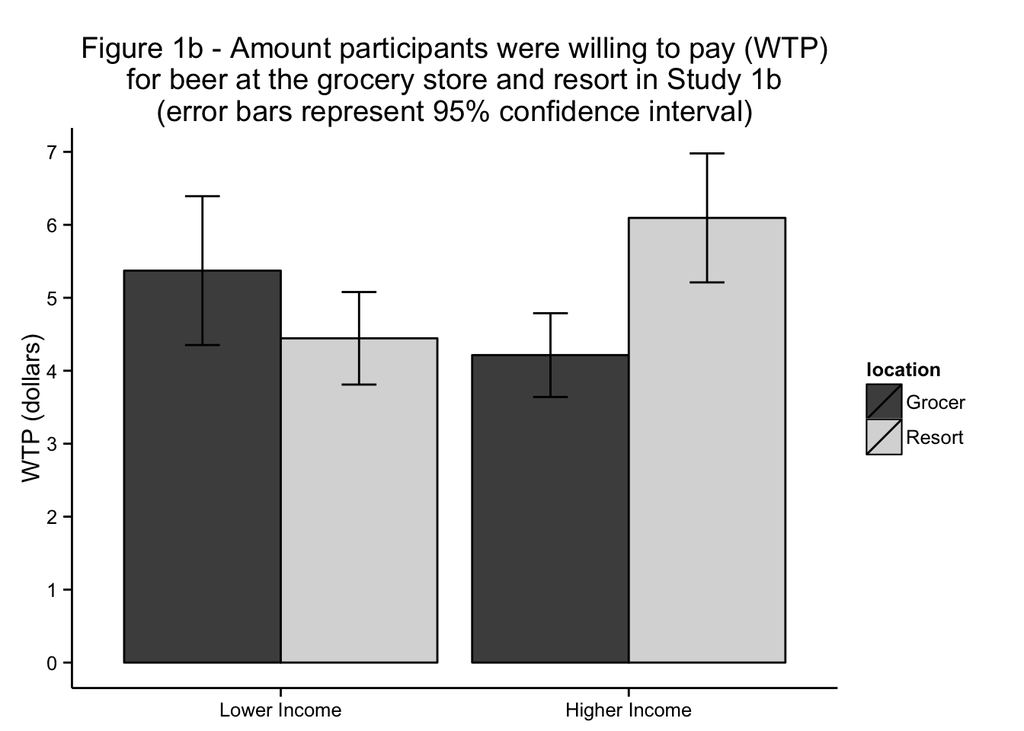

### Study 1c

“We replicated the results of 1b with larger samples in studies 1c and 1d. In study 1c, we excluded 2 participants with missing responses, 5 with unreasonably high WTPs (over $100), and 19 additional outliers on WTP, which left 578 participants.”

```
##   mean.age
## 1     29.9
```

```
## Source: local data frame [2 x 2]
##
##   gender sex_breakdown
## 1      f           246
## 2      m           358
```

```
##   sample.size
## 1         604
```

```
##   median.household.income median.household.size
## 1                   45000                     2
```

```
##   cleaned.sample_size
## 1                 578
```

“Dividing participants according to a median split on income, we found that higher-income participants offered a higher price for beer from the resort,”

```
##   mean.beer ci.low ci.high
## 1      6.81   6.34    7.28
```

“than for beer from the grocery store.”

```
##   mean.beer ci.low ci.high
## 1      5.41   5.04    5.78
```

“Lower-income participants’ WTP did not differ significantly between beer from the resort,”

```
##   mean.beer ci.low ci.high
## 1      5.89   5.48    6.31
```

“and beer from the store.”

```
##   mean.beer ci.low ci.high
## 1      5.56   5.06    6.06
```

“The interaction between income and context was significant, F(1,574) = 5.68, p < 0.05, eta squared partial = 0.01.”

```
##               Df Sum Sq Mean Sq F value   Pr(>F)
## resort         1     94   93.53  13.244 0.000298 ***
## split          1     21   20.77   2.940 0.086924 .
## resort:split   1     40   40.10   5.678 0.017508 *
## Residuals    574   4054    7.06
## ---
## Signif. codes:  0 '***' 0.001 '**' 0.01 '*' 0.05 '.' 0.1 ' ' 1
```

```
## Grocery/Resort & Low/High-Income
## Partial Eta Squared: 0.01
```

“The interaction was also significant when income was treated continuously, beta = 1.65, t(574) = 3.27, p < 0.01.”

```
##                     term beta      p
## 1 scale(resort * logses) 1.65 0.0011
```

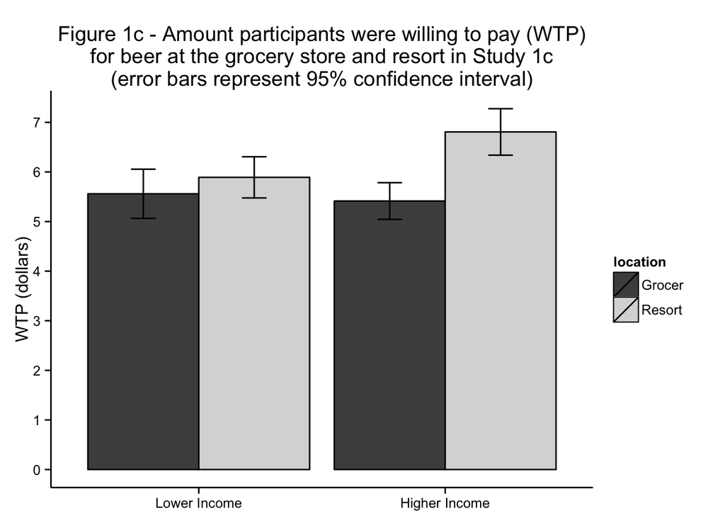

### Study 1d

*note: in our replication, we counted 1,023 females and 992 males - this is a discrepency of +1 female and -1 male.*

```
##   mean.age
## 1     39.1
```

```
## Source: local data frame [2 x 2]
##
##   gender sex_breakdown
## 1      f          1023
## 2      m           992
```

```
##   sample.size
## 1        2015
```

```
##   median.household.income median.household.size
## 1                   55000                     3
```

“In Study 1d (the nationally representative sample), a large number of participants reported unreasonably high WTPs, and exclusions based on the rules set for the smaller samples in previous studies would have left many unreasonable prices in the data set. We therefore included in our analyses only those participants with a WTP of $20 or less, which seemed like the upper bound of a reasonable price. This set a cutoff price similar to the cutoff price based on the stand deviations in Studies 1b and 1c. After this exclusion and the exclusion of 4 additional participants who were outlines on income, the final sample included 1,898 participants.”

```
##   cleaned.sample.size
## 1                1898
```

“Dividing participants according to a median split on income, we found that higher-income participants offered a higher price for feer from the resort (M = $6.80, 95% CI [$6.41, $7.18]),”

```
##   mean.wtp CI.low CI.high
## 1      6.8   6.41    7.18
```

“than for beer from the grocery store (M = $5.46, 95% CI [$5.13, $5.79]).”

```
##   mean.wtp CI.low CI.high
## 1     5.46   5.13    5.79
```

“Lower-income participants’ WTP did not differ significantly between the resort (M = $6.21, 95% CI [$5.83, $6.60])”

```
##   mean.wtp CI.low CI.high
## 1     6.21   5.83     6.6
```

“and the store (M = %5.71, 95% CI [$5.31, $6.11]).”

```
##   mean.wtp CI.low CI.high
## 1     5.71   5.31    6.11
```

```
##                Df Sum Sq Mean Sq F value   Pr(>F)
## resort          1    389   388.8  22.559 2.19e-06 ***
## split           1     12    12.3   0.716   0.3975
## resort:split    1     83    83.0   4.817   0.0283 *
## Residuals    1894  32647    17.2
## ---
## Signif. codes:  0 '***' 0.001 '**' 0.01 '*' 0.05 '.' 0.1 ' ' 1
```

```
## Grocery/Resort & Low/High-Income
## Partial Eta Squared: 0.003
```

“This interaction was marginally significant when income was treated continuously, beta = 0.50, t(1894) = 1.85, p < 0.07.”

```
##                     term beta      p
## 1 scale(resort * logses)  0.5 0.0649
```

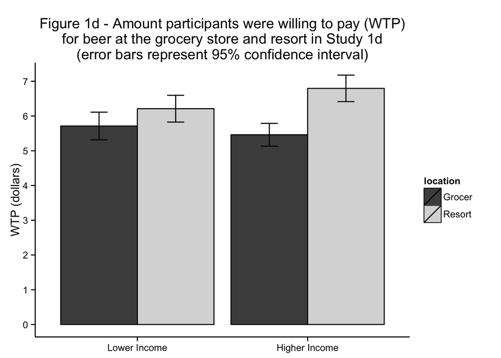

“The beer-on-the-beach scenario provides a canonical example of the difficulty people have in translating utility into value. People have a sense of how much they would enjoy the beer, but they have difficulty representing this enjoyment with a price. However, under conditions of scarcity, people base their price not merely on anticipated enjoyment, but also on anticipated trade-offs, and those are more consistent guides for valuation. Could scarcity also lead to more consistent valuation of a dollar itself? The next set of studies addressed this question.”

### Replicator’s Note - Graphs from here on out are newly added by us. We feel that these figure strongly convey the findings in each experiment, namely, those with more resources are sensitive to experimental priming to change value measure, and those with scarce resources have a stable measure of value, independent of experimental priming. With figures for each experiment, the paper’s conclusion is more throughly driven to the reader.

### Study 2a

“In Study 2a, there were 238 participants.”

```
##   sample.size median.ses
## 1         238   25980.76
```

```
##   mean.age
## 1     30.7
```

```
## Source: local data frame [2 x 2]
##
##   V4 sex_breakdown
## 1  f            96
## 2  m           142
```

```
##   median.household.income median.household.size
## 1                   45000                     2
```

“One participant was excluded as an outlier on income.”

```
##   cleaned.sample.size
## 1                 237
```

“We conducted binary logistic regressions to comepare the frequency with which participants cited each of the two considerations of interest (trade-offs vs proportional discount) as a function of income. Higher-income participants were more likely than lower-income participants to use proportional thinking, beta = 0.87, Wald-test chi square (1, N = 237) = 4.02, p < 0.05.”"

```
##    term beta      p
## 1 lgses 0.87 0.0449
```

```
##  chi2
## 4.021
```

“but lower-income participants were more likely than higher-income participants to use trade-off thinking, beta = -0.96, Wald-test chi square (1, N = 237) = 4.69, p < 0.05.”

```
##    term  beta      p
## 1 lgses -0.96 0.0304
```

```
##  chi2
## 4.689
```

### Study 2b

“In study 2b there were 705 participants (mean age = 30.0 years; 290 females, 415 males; median household size = 3 people; median household income = $45,000). The participants in Study 2c were the same participants as in Study 1d (and analyses were limited to the same participants, but including all participants did not change the results). Note that participants completed Studies 1d and 2c in a counterbalanced order. Participants in Studies 2b and 2c responded to the same scenario as did participants in Study 2a, but they stated whether they would travel for the discount.”

```
##   meanAge
## 1      30
```

```
## Source: local data frame [2 x 2]
##
##   gender sexBreakdown
## 1      f          290
## 2      m          415
```

```
##   sampleSize
## 1        705
```

```
##   medianHouseholdIncome medianHouseholdSize
## 1                 45000                   3
```

*Results* ***

“In Study 2b, 1 participant was excluded for missing responses, and 2 were excluded as outliers on income.”

```
##   cleanedSampleSize
## 1               702
```

“The analyses conducted were based on a median split on income. Confirming earlier findings, these analyses revealed that higher-income participants were more willing to travel when the discount was proportionally larger (i.e., the tablet cost less): Specifically, 86%, 75%, and 58% would travel when the tablet cost $300, $500, and $1,000, respectively.”

```
##   threehundredGo
## 1       85.95041
```

```
##   fivehundredGo
## 1       75.4386
```

```
##   onethousandGo
## 1      58.40708
```

“Lower-income participants were less sensitive to the proportional size of the discount: The corresponding percentages of lower-income participants willing to travel were 78%, 67%, and 67%.”

```
##   threehundredGo
## 1       77.77778
```

```
##   fivehundredGo
## 1      67.22689
```

```
##   onethousandGo
## 1      66.94915
```

[figure not shown]

“The ineraction between income and context was significant in a binary logistic regression, beta = -0.48, Walt-test chi square (1, N = 702) = 4.93, p < 0.05,”

```
##         term  beta      p
## 1 split:cond -0.48 0.0265
```

```
##  chi2
## 4.925
```

“and was marginally significant when income was treated continuously, beta = -0.57, Wald-test chi square(1, N - 702) = 3.32, p < 0.07.”

```
##          term  beta      p
## 1 logses:cond -0.57 0.0686
```

```
##  chi2
## 3.315
```

### Study 2c

“Five participants were excluded for missing responses in Study 2c, so 1,893 participants were included in the analyses.”

```
##   cleaned.sample.size
## 1                1893
```

“Analyses based to a median split on income revealed a more muted trend than in the previous study. Among higher-income participants, 71%, 67%, and 51% were willing to travel when the tablet cost $300, $500, and $1,000, respectively;”

```
##   threehundred.go
## 1        71.29909
```

```
##   fivehundred.go
## 1       67.34007
```

```
##   onethousand.go
## 1       51.14754
```

“among lower-income participants, the corresponding percentages were 70%, 69%, and 55%.”

```
##   threehundred.go
## 1        70.27027
```

```
##   fivehundred.go
## 1       68.73156
```

```
##   onethousand.go
## 1       55.38462
```

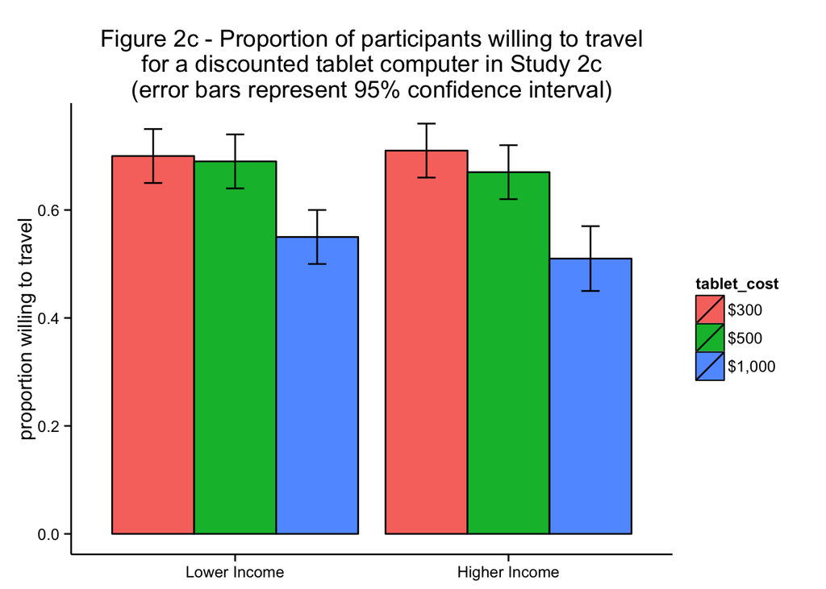

“When income was treated continuously, the interaction between income and context was clear, beta = -0.39, Wald-test chi square(1, N = 1,893) = 6.13, p < 0.05.”

```
##               term  beta      p
## 1 logses:webercond -0.39 0.0133
```

```
##  chi2
## 6.133
```

### Study 2d

“In Study 2d, there were 301 participants (mean age = 30.2 years; 120 females, 181 males; median household size = 3 people; median household income = $25,000).”

```
##   n()
## 1 301
```

```
##   mean(age, na.rm = T)
## 1                 30.2
```

```
## Source: local data frame [2 x 2]
##
##   gender n()
## 1      f 120
## 2      m 181
```

*Note: median household size and median income do not match the publication. We also ran these calculations in excel and SPSS and all three match what is below, and do not match what is published*

```
##   median(house)
## 1             2
```

```
##   median(inc2)
## 1        35000
```

*Results* ***

“We regressed willingness to travel on income (categorized by a median split), proportional size of the discount (large vs. small), absolute size of the discount ($10 vs. $150), all two-way interaction terms, and the three-way interaction term.”

```r
# Regression
glm(go ~ split * lgdiscount * lgsavings,
    data = df2d_1,
    family = "binomial")
```

“Higher-income participants were significantly more willing to travel for a proportionally larger discount (60%) than for a proportionally smaller discount (41%),”

```
##   highPropLarge
## 1            60
```

```
##   highPropSmall
## 1            41
```

“but this was not true for lower-income participants (50% vs. 61%).”

```
##   higgPropLarge
## 1            50
```

```
##   highPropSmall
## 1            61
```

“The interaction between proportional discount and income was significant, β = −1.90, Wald-test χ2(1, N = 301) = 4.11, p < .05.”

```
##               term beta    p
## 1 split:lgdiscount -1.9 0.04
```

```
## chi2
## 4.11
```

“Note that this interaction did not depend on the absolute amount of the discount, as the three-way interaction was not significant, β = −0.89, Wald-test χ2(1, N = 301) = 0.28, p > .6.”

```
##                         term  beta      p
## 1 split:lgdiscount:lgsavings -0.89 0.6003
```

```
##  chi2
## 0.275
```

“When income was treated continuously, the interaction between proportional discount and income also emerged, but was not significant, β = −2.13, Wald-test χ2(1, N = 301) = 2.21, p < .15.”

```
##               term  beta      p
## 1 lgses:lgdiscount -2.13 0.1372
```

```
##  chi2
## 2.209
```

### Study 3

“In Study 3, there were 505 participants (mean age = 33.0 years; 208 females, 297 males; median household size = 3 people; median household income = $45,000).”

```
##   n()
## 1 505
```

```
##   mean(age, na.rm = T)
## 1                   33
```

```
## Source: local data frame [2 x 2]
##
##   gender n()
## 1      f 208
## 2      m 297
```

```
##   median(house)
## 1             3
```

```
##   median(inc2)
## 1        45000
```

“One participant was excluded for missing responses, and another was excluded as an outlier on income.”

```
##   cleanedSampleSize
## 1               503
```

“Analyses based on a median split on income replicated earlier results. Higher-income individuals rated the loss gamble as significantly more attractive (M = 11.63, 95% CI = [10.56, 12.69]) than the no-loss gamble (M = 8.33, 95% CI = [7.62, 9.04]),”

```
##   meanJudgeHighIncomeLossGamble CI.low CI.high
## 1                         11.63  10.56   12.69
```

```
##   meanJudgeHighIncomenoLossGamble CI.low CI.high
## 1                            8.33   7.62    9.04
```

“but this difference was smaller for lower-income individuals (loss gamble: M = 10.38, 95% CI = [9.38, 11.38], no-loss gamble: M = 9.18, 95% CI = [8.31, 10.05]).”

```
##   meanJudgeLowIncomeLossGamble CI.low CI.high
## 1                        10.38   9.38   11.38
```

```
##   meanJudgeLowIncomeNoLossGamble CI.low CI.high
## 1                           9.18   8.31   10.05
```

[figure not shown]

“The interaction between gamble and income was significant, F(1, 499) = 5.04, p < .05, ηp2 = .01.”

```
##                  Df Sum Sq Mean Sq F value   Pr(>F)
## split             1      1     1.2   0.044   0.8345
## smallloss         1    633   633.5  23.190 1.95e-06 ***
## split:smallloss   1    138   137.7   5.040   0.0252 *
## Residuals       499  13631    27.3
## ---
## Signif. codes:  0 '***' 0.001 '**' 0.01 '*' 0.05 '.' 0.1 ' ' 1
```

```
## Low-/High-Income & Loss-/No-loss-gamble
## partial eta squared: 0.01
```

“The interaction was also significant when income was treated continuously, β = 1.13, t(499) = 2.21, p < .05.”

```
##                        term  beta      p
## 1 scale(logses * smallloss) 1.125 0.0278
```

### Study 4

“In Study 4, there were 263 participants (mean age = 31.6 years; 102 females, 161 males; median household size = 3 people; median household income = $45,000).”

```
##   n()
## 1 263
```

```
##   mean(Age, na.rm = T)
## 1                 31.6
```

```
## Source: local data frame [2 x 2]
##
##   Gender n()
## 1      f 102
## 2      m 161
```

```
##   median(House)
## 1             3
```

```
##   median(Income2)
## 1           45000
```

“Four participants were excluded for not completing the prime question.”

```
##   Subject
## 1      56
## 2      75
## 3     112
## 4     236
```

```
##   cleaned.sample.size
## 1                 259
```

“When we analyzed the data using a median split based on income, higher-income participants rated the DVD as significantly more expensive when they thought about a small account (M = 5.74, 95% CI = [5.04, 6.44]) rather than a large account (M = 4.47, 95% CI = [3.93, 5.01]),”

```
##   mean.expense.highincome.smallaccount CI.low CI.high
## 1                                 5.74   5.04    6.44
```

```
##   mean.expense.highincome.largeaccount CI.low CI.high
## 1                                 4.47   3.93    5.01
```

“whereas the evaluations of lower-income participants did not differ significantly between the conditions (small account: M = 5.55, 95% CI = [4.92, 6.18]; large account: M = 5.75, 95% CI = [5.03, 6.48]).”

```
##   mean.expense.lowincome.smallaccount CI.low CI.high
## 1                                5.55   4.92    6.18
```

```
##   mean.expense.lowincome.largeaccount CI.low CI.high
## 1                                5.75   5.03    6.48
```

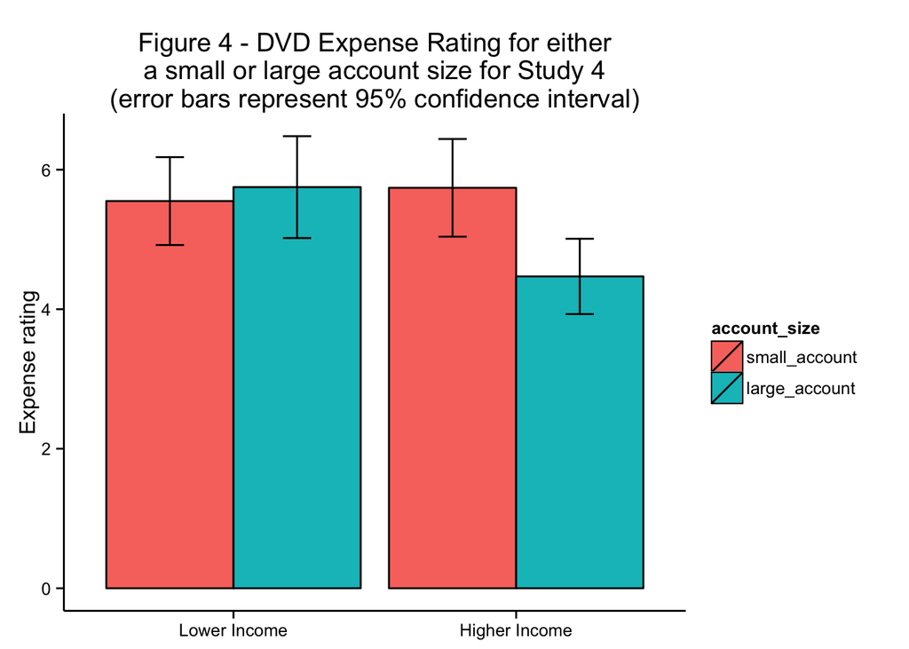

“The interaction between income and condition was significant, F(1, 255) = 4.96, p < .05, ηp2 = .02.”

```
##                  Df Sum Sq Mean Sq F value Pr(>F)
## Large.Acc         1   20.4   20.37   2.897 0.0899 .
## Split             1   19.2   19.22   2.733 0.0995 .
## Large.Acc:Split   1   34.9   34.88   4.961 0.0268 *
## Residuals       255 1793.1    7.03
## ---
## Signif. codes:  0 '***' 0.001 '**' 0.01 '*' 0.05 '.' 0.1 ' ' 1
```

```
## Small-/Large-account & Low-/High-Income
## Partial Eta-squared: 0.019
```

“The interaction was also significant when income was treated as a continuous variable, β = 2.43, t(255) = 3.39, p < .01.”

*Note: beta estimate and t value are negative, but are reported as positive*

```
##                       term  beta     p
## 1 scale(largeacc * logses) -2.43 8e-04
```

### Study 5

“In Study 5, there were 234 participants (mean age = 31.8 years; 107 females, 127 males)”

```
##   n()
## 1 234
```

```
## Source: local data frame [2 x 2]
##
##   gender n()
## 1      f 107
## 2      m 127
```

“No participants were excluded from the analyses. We first analyzed responses using a median split on participants’ dieting behavior. Nondieters rated the fries as more fattening when they thought about a small account (M = 8.64, 95% CI = [8.20, 9.07]) than when they thought about a large account (M = 7.80, 95% CI = [7.21, 8.38]),”

```
##   mean.fattening.nondieters.smallaccount CI.low CI.high
## 1                                   8.64    8.2    9.07
```

```
##   mean.fattening.nondieters.largeaccount CI.low CI.high
## 1                                    7.8   7.21    8.38
```

“but this was not true for dieters (small account: M = 8.86, 95% CI = [8.29, 9.43]; large account: M = 9.13, 95% CI = [8.66, 9.60]).”

```
##   mean.fattening.dieters.smallaccount CI.low CI.high
## 1                                8.86   8.29    9.43
```

```
##   mean.fattening.dieters.largeaccount CI.low CI.high
## 1                                9.13   8.66     9.6
```

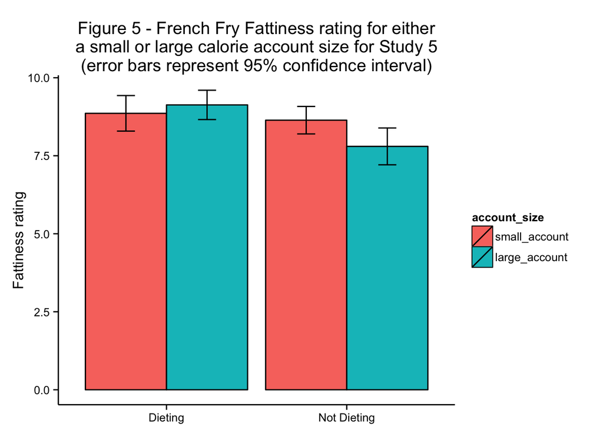

“The interaction between dieting status and condition was significant, F(1, 230) = 4.40, p < .05, ηp2 = .02,”

```
##              Df Sum Sq Mean Sq F value  Pr(>F)
## split         1   32.6   32.62   8.122 0.00477 **
## week          1    6.7    6.69   1.667 0.19796
## split:week    1   17.7   17.66   4.397 0.03710 *
## Residuals   230  923.6    4.02
## ---
## Signif. codes:  0 '***' 0.001 '**' 0.01 '*' 0.05 '.' 0.1 ' ' 1
```

```
## Small-/Large-Account & Not-/Is-Dieting
## Partial eta squared: 0.019
```

“and the interaction was also found when dieting behavior was treated continuously, β = 0.43, t(230) = 2.11, p < .05.”

```
##                term beta      p
## 1 scale(log * week) 0.43 0.0364
```

### Study 6

“In Study 6, there were 74 participants (mean age = 32.0 years; 46 females, 28 males).”

```
##   n()
## 1  74
```

```
##   mean(Age, na.rm = T)
## 1                   32
```

```
## Source: local data frame [2 x 2]
##
##   Gender n()
## 1      f  46
## 2      m  28
```

“One participant was excluded because of a computer malfunction during the game (not specifically indicated, we deduced based on raw data that this was Subject #16).”

```
##   n_distinct(Subject)
## 1                  73
```

```
##   cleaned.sample.size
## 1                  73
```

“Time-rich participants rated the loss as more expensive when they thought about a small account (M = 8.31, 95% CI = [7.78, 8.84]) than when they thought about a large account (M = 6.50, 95% CI = [5.42, 7.58]),”

```
##   mean.expense.timerich.smallaccount CI.low CI.high
## 1                               8.31   7.78    8.84
```

```
##   mean.expense.timerich.largeaccount CI.low CI.high
## 1                                6.5   5.42    7.58
```

“whereas time-poor participants’ evaluations did not differ between the small-account condition (M = 8.33, 95% CI = [7.14, 9.52]) and the large- account condition (M = 8.83, 95% CI = [7.97, 9.69]).”

```
##   mean.expense.timepoor.smallaccount CI.low CI.high
## 1                               8.33   7.14    9.52
```

```
##   mean.expense.timepoor.largeaccount CI.low CI.high
## 1                               8.83   7.98    9.69
```

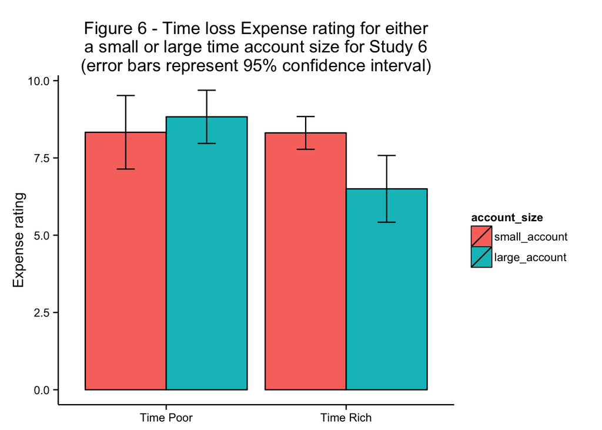

“A 2 (scarcity condition) × 2 (account condition) analysis of variance revealed a significant interaction, F(1, 69) = 5.16, p < .05, ηp2 = .07.”

```
##             Df Sum Sq Mean Sq F value Pr(>F)
## large        1    7.9   7.892   1.685 0.1985
## slack        1   24.8  24.832   5.303 0.0243 *
## large:slack  1   24.2  24.172   5.162 0.0262 *
## Residuals   69  323.1   4.683
## ---
## Signif. codes:  0 '***' 0.001 '**' 0.01 '*' 0.05 '.' 0.1 ' ' 1
```

```
## Small-/Large-Account & Time-Poor/-Rich
## Partial eta squared: 0.07
```

> End of replication.